# Hands-on part1 : Metaphlan4

```r
# Load libraries
library(tidyverse)
library(mia)
library(scater)
# Load datasets
metadata <- read_csv("../../datasets/pingu_metadata.csv") %>%
  column_to_rownames(var="NCBI_accession") %>%
  mutate(age_cat=paste(as.character(infant_age), "days", sep=" "))
mpa_default <- read_tsv("../../datasets/pingu_mpadefault_abundance_table.txt", skip=1) # skip the first line of mpa output (database name)
mpa_withunknown <- read_tsv("../../datasets/pingu_mpaunclass_abundance_table.txt", skip=1)
```

## Structure of Metaphlan4 output

Let’s first take a peak at the Metaphlan4 output table. The output table contains the taxonomy in the “clade_name” column. Taxa are rows and samples are columns. The default output gives you the relative abundances of each taxa in the samples.

Let’s sum the counts of the first sample “SRR22212915”.

```r
sum(mpa_default$SRR22212915)
```

```
[1] 800
```

**Question: Take a look at the mpa table to understand why the counts do not sum to 100 as expected.**

## Parse the Metaphlan4 output

Let’s parse the Metaphlan4 output to create a data container for Mia. Fortunately for us, the miaverse contain a function to directly import the metaphlan4 output into the data object.

```r
tse # get a summary of the TSE contents
```

```
class: TreeSummarizedExperiment
dim: 566 116
metadata(0):
assays(1): counts
rownames(566): Bifidobacterium_longum Bifidobacterium_breve ... GGB4260_SGB5796
  Corynebacterium_amycolatum
rowData names(9): Kingdom Phylum ... Strain clade_name
colnames(116): SRR22212915 SRR22212916 ... SRR22213129 SRR22213131
colData names(25): subject_id family_role ... lifestyle age_cat
reducedDimNames(0):
mainExpName: NULL
altExpNames(7): Kingdom Phylum ... Genus Species
rowLinks: NULL
rowTree: NULL
colLinks: NULL
colTree: NULL
```

```r
taxonomyRanks(tse) # see how many taxonomic ranks we have in the TSE
```

```
[1] "Kingdom" "Phylum"  "Class"   "Order"   "Family"  "Genus"   "Species"
```

## Metaphlan4 sample exploration

### Alpha-diversity analysis

Let’s start with a good old alpha-diversity overview. In infant gut microbiome we expect an increase in richness and alpha-diversity during the gut microbiota maturation…

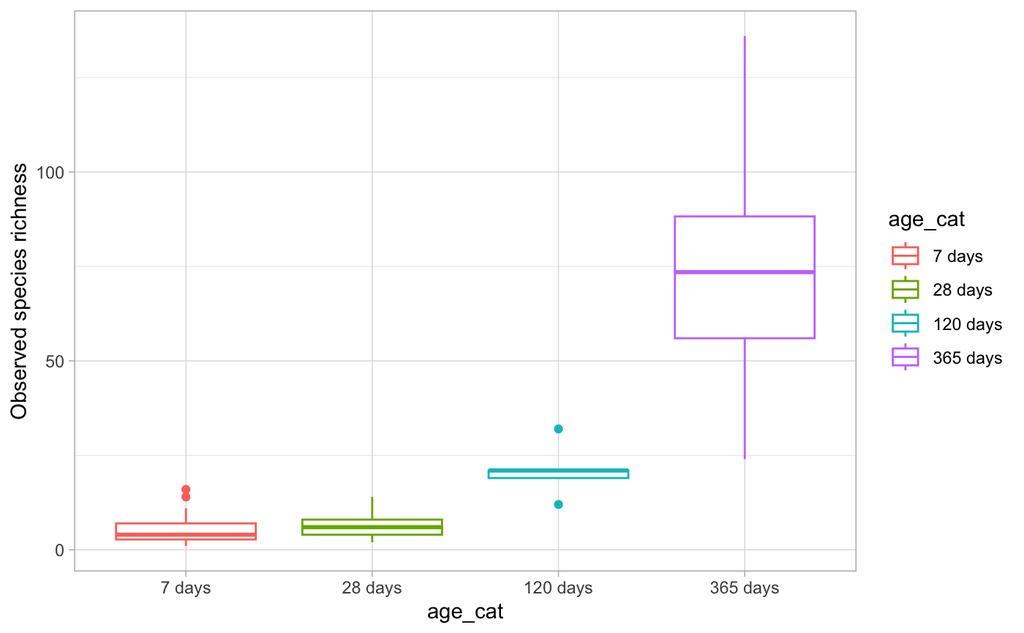

```r
tse <- mia::estimateRichness(tse, assay.type = "counts", index = "observed", name="observed")
tse <- mia::estimateDiversity(tse, assay.type = "counts",index = "shannon", name = "shannon")

div_melt <- as.data.frame(tse$observed) %>%
  dplyr::rename("Observed_richness"="tse$observed") %>%
  rownames_to_column("SampleID")

aplha_melt <- as.data.frame(tse$shannon) %>%
  dplyr::rename("Shannon index"="tse$shannon") %>%
  rownames_to_column("SampleID")

metadata_samples <- metadata %>%
  rownames_to_column("SampleID")

plot_data <- dplyr::full_join(div_melt, metadata_samples)
plot_data <- dplyr::full_join(aplha_melt, plot_data)
plot_data$age_cat <- factor(plot_data$age_cat, levels = c("7 days", "28 days", "120 days", "365 days"))
plot_data %>% ggplot(aes(x=age_cat, y=Observed_richness, color=age_cat)) +
  geom_boxplot() +
  theme_light() +
  ylab("Observed species richness")
```

**Question: plot the alpha-diversity (shannon index)**

### Community composition analysis

Now, let’s take a look at the relative abundances of the samples, grouped by infant age group.

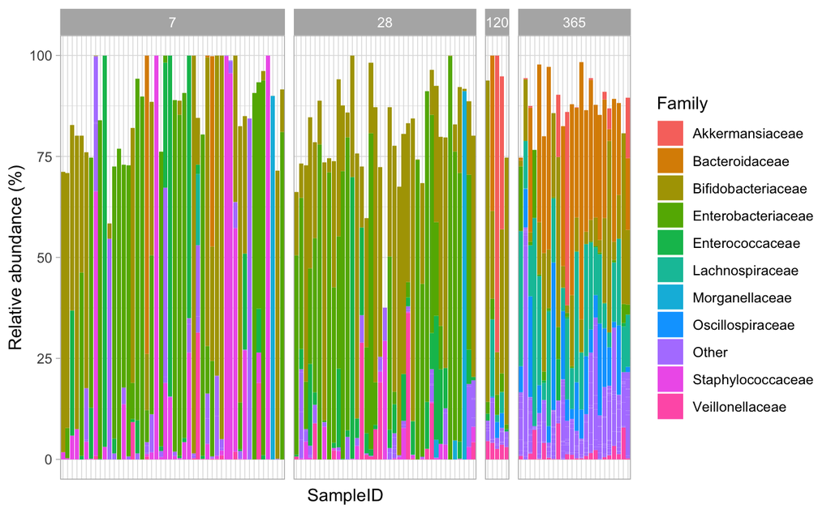

```r
# Getting top taxa on a Family level
tse_family <- mergeFeaturesByRank(tse, rank ="Family", onRankOnly=TRUE)
top_taxa <- getTopFeatures(tse_family, top = 10)

# Renaming the "Phylum" rank to keep only top taxa and the rest to "Other"
family_renamed <- lapply(rowData(tse_family)$Family,
                   function(x){if (x %in% top_taxa) {x} else {"Other"}})
rowData(tse_family)$Family <- as.character(family_renamed)

molten_tse <- mia::meltAssay(tse_family,
                        add_row_data = TRUE,
                        add_col_data = TRUE,
                        assay.type = "counts")

# Visualizing the composition barplot, with samples order by "Bacteroidetes"
molten_tse %>% ggplot(aes(x=SampleID, y=counts, fill=Family)) +
  geom_bar(stat="identity") +
  facet_grid(.~infant_age, scales="free", space="free") +
  theme_light() +
    theme(axis.text.x=element_blank(),
      axis.ticks.x=element_blank()) +
  ylab("Relative abundance (%)")
```

**Question: Subset the samples to include only samples from 7 day of age and look at the community composition of the samples from premature vs full term infants**

### Unsupervised ordination

Finally, let’s get an overview of the samples using a PCoA with Bray-Curtis distances at the species level.

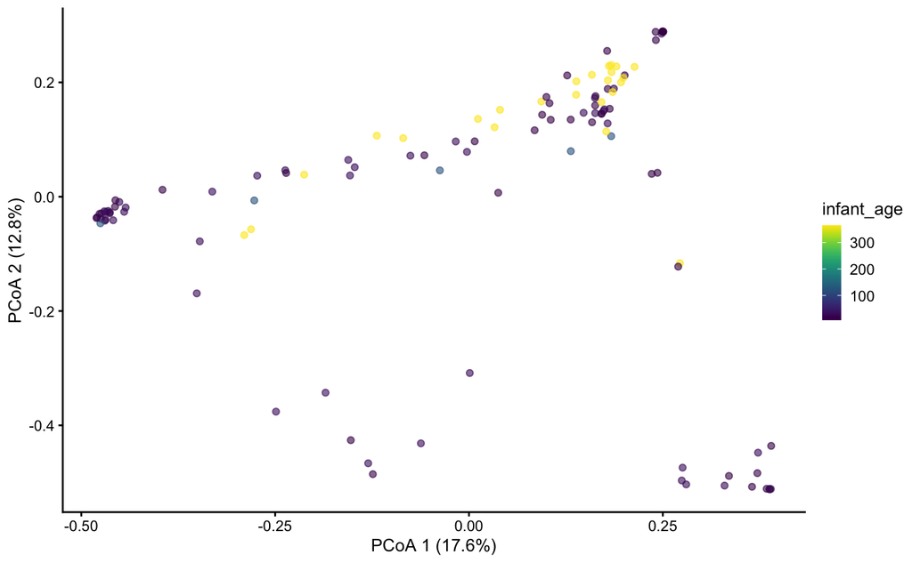

```r
tse <- runMDS(tse,
              FUN = vegan::vegdist,
              method = "bray",
              assay.type = "counts",
              name = "MDS_bray")

# Calculate explained variance
e <- attr(reducedDim(tse, "MDS_bray"), "eig")
rel_eig <- e / sum(e[e > 0])

plotReducedDim(tse, "MDS_bray", colour_by = "infant_age")+
  labs(x = paste("PCoA 1 (", round(100 * rel_eig[[1]], 1),"%", ")", sep = ""),
       y = paste("PCoA 2 (", round(100 * rel_eig[[2]], 1), "%", ")", sep = ""))
```

## Next steps:

**Question: use the metaphlan4 output containing the estimation of the unclassified reads, what differences can you see?**